# Cluster Analysis and Decision Tree Induction

#### Reading the training data from csv file

```r
library(tidyverse)
wfor_train <- read_csv("Weather Forecast Training.csv", col_types = cols())
attr(wfor_train, 'spec') <- NULL
```

#### Size of the training dataset

```r
dim(wfor_train)
```

```
## [1] 51978    16
```

#### Internal sturcture of the weather forecast training dataset

```r
str(wfor_train)
```

```
## Classes 'spec_tbl_df', 'tbl_df', 'tbl' and 'data.frame': 51978 obs. of  16 variables:
##  $ Location     : chr  "NorahHead" "Nuriootpa" "GoldCoast" "Bendigo" ...
##  $ MinTemp      : num  18.9 11.1 15.9 0 9.1 6.6 9.7 17.1 13.5 12.5 ...
##  $ MaxTemp      : num  23.7 20.8 19.5 14.9 22.7 16.3 20.6 21.9 23.5 21.3 ...
##  $ Rainfall     : num  0 0 17.6 0 0 ...
##  $ Evaporation  : num  NA 4.8 NA NA NA 3.4 1 NA 6.8 NA ...
##  $ Sunshine     : num  NA 8.3 NA NA NA 6.9 4.2 0 6.5 NA ...
##  $ WindGustDir  : chr  "SSE" "W" "SE" "WSW" ...
##  $ WindGustSpeed: num  41 39 44 35 41 50 61 54 46 65 ...
##  $ WindDir      : chr  "SSE" "WSW" "SW" "WNW" ...
##  $ WindSpeed    : num  28 26 9 19 7 30 20 28 19 22 ...
##  $ Humidity     : num  55 48 99 55 40 55 35 99 53 82 ...
##  $ Pressure     : num  1026 1014 1028 1023 1027 ...
##  $ Cloud        : num  NA 7 NA 4 NA 7 7 8 6 NA ...
##  $ Temp         : num  22.4 19.5 17.8 14.2 22.5 14.6 19.5 17.9 22.2 13.1 ...
##  $ RainToday    : chr  "No" "No" "Yes" "No" ...
##  $ RainTomorrow : chr  "Yes" "No" "Yes" "Yes" ...
```

## Section 1: Data preparation

#### Data quality issues

##### Missing values

```r
sum(!complete.cases(wfor_train))
```

```
## [1] 30891
```

The data can be grouped based on location and missing values can be replaced with mean of their respective attributes for that location. This makes sure that the data is precise with respect to location.

```r
library(dplyr)
impute.mean <- function(x) replace(x, is.na(x), round(mean(x, na.rm = TRUE),1))
wfor_train <- wfor_train %>%
  group_by(Location) %>%
  mutate(
    MinTemp = impute.mean(MinTemp),
    MaxTemp = impute.mean(MaxTemp),
    Rainfall = impute.mean(Rainfall),
    Evaporation = impute.mean(Evaporation),
    Sunshine = impute.mean(Sunshine),
    WindGustSpeed = round(impute.mean(WindGustSpeed)),
    WindSpeed = round(impute.mean(WindSpeed)),
    Humidity = round(impute.mean(Humidity)),
    Pressure = round(impute.mean(Pressure)),
    Cloud = round(impute.mean(Cloud)),
    Temp = impute.mean(Temp)
  )
```

In some cases the missing values are replaced by NaN as there are no values for the attribute for that particular location. Such values can be replaced with the mean of the attribute by considering the entire dataset, avoiding lose of interesting data.

```r
wfor_train$Evaporation <- impute.mean(wfor_train$Evaporation)
wfor_train$Sunshine <- impute.mean(wfor_train$Sunshine)
wfor_train$WindGustSpeed <- impute.mean(wfor_train$WindGustSpeed)
wfor_train$Pressure <- round(impute.mean(wfor_train$Pressure))
wfor_train$Cloud <- round(impute.mean(wfor_train$Cloud))
```

In case of categorical variables like wind direction missing values are replaced with mode of the attribute based on location.

```r
impute.mode <- function(x) {
   uni <- unique(x)
   mod <- uni[which.max(tabulate(match(x, uni, incomparables = NA)))]
   replace(x, is.na(x), mod)
}
wfor_train <- wfor_train %>%
  group_by(Location) %>%
  mutate(
    WindGustDir = impute.mode(WindGustDir),
    WindDir = impute.mode(WindDir),
    RainToday = impute.mode(RainToday)
    )
```

Categorical variables that still contain missing values are replaced with the mode for the entire dataset.

```r
wfor_train$WindGustDir <- impute.mode(wfor_train$WindGustDir)
```

```r
sum(!complete.cases(wfor_train))
```

```
## [1] 0
```

##### Duplicate data

```r
nrow(wfor_train[duplicated(wfor_train), ])
```

```
## [1] 21
```

Removing the 21 duplicate records from the dataset.

```r
wfor_train <- wfor_train %>%
  distinct(.keep_all = TRUE)

nrow(wfor_train[duplicated(wfor_train), ])
```

```
## [1] 0
```

##### Transforming categorical attributes to numerical attributes

```r
library(onehot)
encoder <- onehot(wfor_train, stringsAsFactors = TRUE, max_levels = 20)
training <- data.frame(predict(encoder, wfor_train))
```

#### Exploratory Data Analysis

How does humidity vary with temperature?

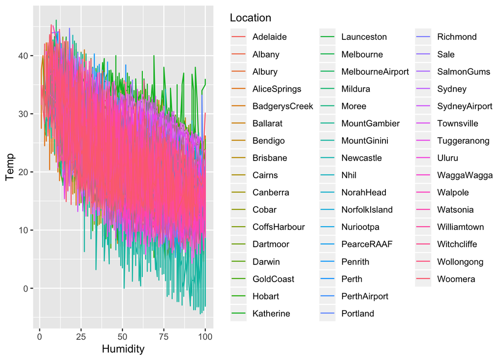

```r
library(ggplot2)
ggplot(wfor_train, aes(x = Humidity, y = Temp, group = Location, color = Location)) +
geom_line()
```

As temperature increases, humidity is likely to decrease

What is the proportion of RainToday?

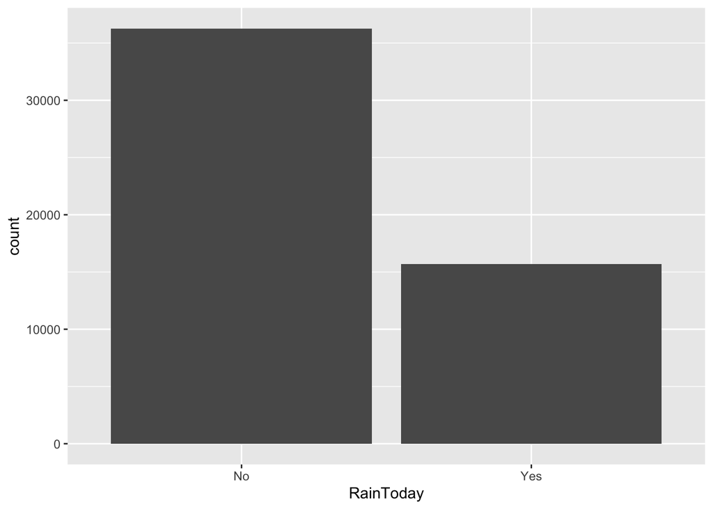

```r
ggplot(wfor_train) +
  geom_bar(aes(x = RainToday))
```

## Section 2: Build, tune and evaluate cluster analysis and decision tree models

#### K-means clustering

Running k-means clustering algorithm on the entire dataset with 2 centroids.

```r
library(factoextra)
t1 <- scale(training, center = TRUE, scale = TRUE)

km_output <- kmeans(t1, centers = 2, nstart = 25, iter.max = 10, algorithm = "Hartigan-Wong")
str(km_output)
```

```
## List of 9
##  $ cluster     : int [1:51957] 1 1 2 2 1 2 1 2 2 2 ...
##  $ centers     : num [1:2, 1:47] 0.0572 -0.0624 0.4125 -0.4502 -0.293 ...
##   ..- attr(*, "dimnames")=List of 2
##   .. ..$ : chr [1:2] "1" "2"
##   .. ..$ : chr [1:47] "MinTemp" "MaxTemp" "Rainfall" "Evaporation" ...
##  $ totss       : num 2441932
##  $ withinss    : num [1:2] 1171146 1100096
##  $ tot.withinss: num 2271241
##  $ betweenss   : num 170691
##  $ size        : int [1:2] 27113 24844
##  $ iter        : int 1
##  $ ifault      : int 0
##  - attr(*, "class")= chr "kmeans"
```

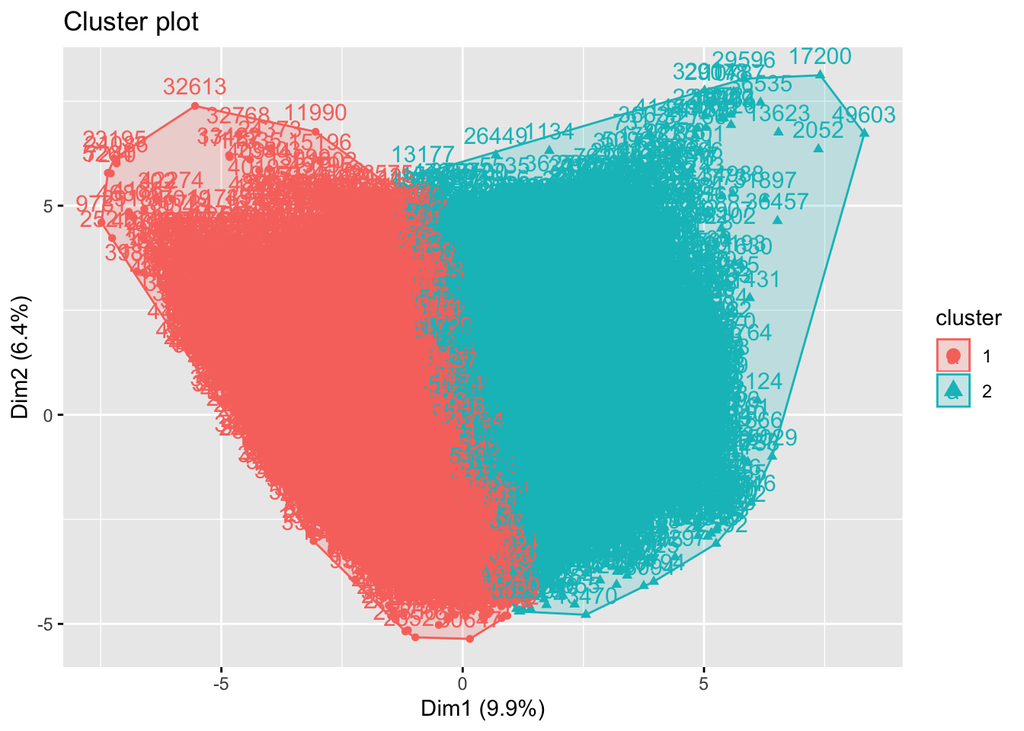

```r
fviz_cluster(km_output, data = t1)
```

##### Elbow method to optimize number of clusters

1. Entire dataset

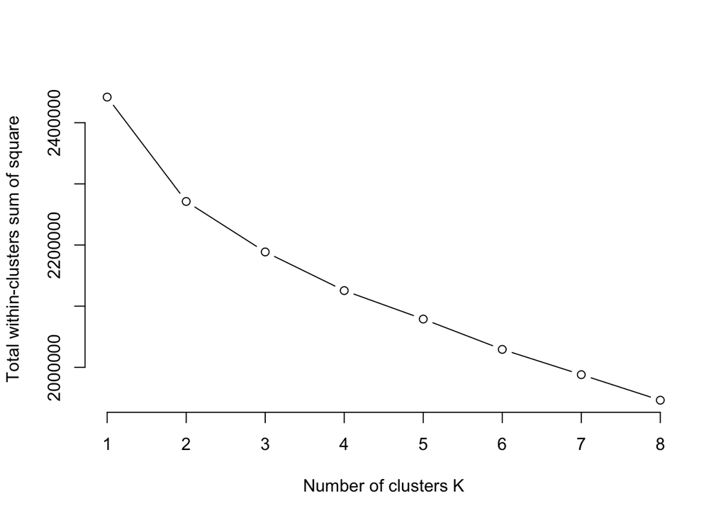

```r
set.seed(10)
wss <- function(k){
  return(kmeans(t1, k, nstart = 25)$tot.withinss)
}

k_values <- 1:8

wss_values <- purrr::map_dbl(k_values, wss)

plot(x = k_values, y = wss_values,
     type = "b", frame = F,
     xlab = "Number of clusters K",
     ylab = "Total within-clusters sum of square")
```

The optimal number of clusters is 2 for the entire dataset.

2. Excluding dummies

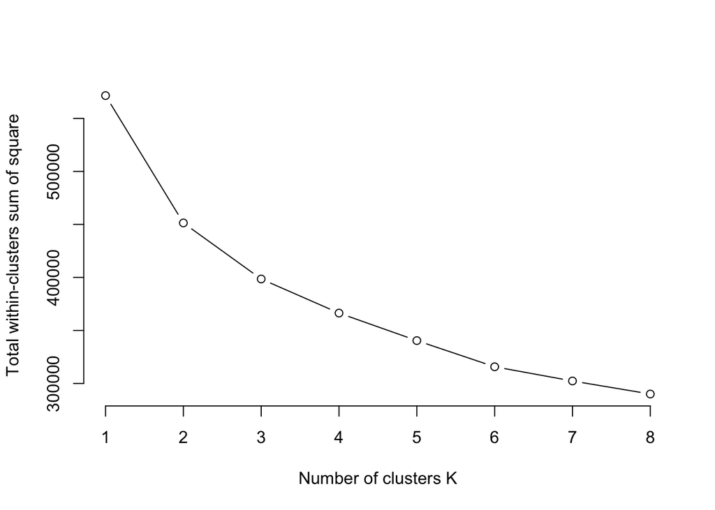

```r
t2 <- t1[ , -c(6:21, 23:38, 44:47)]
set.seed(10)
wss <- function(k){
  return(kmeans(t2, k, nstart = 25)$tot.withinss)
}

k_values <- 1:8

wss_values <- purrr::map_dbl(k_values, wss)

plot(x = k_values, y = wss_values,
     type = "b", frame = F,
     xlab = "Number of clusters K",
     ylab = "Total within-clusters sum of square")
```

The optimal number of clusters is 2 for the dataset without the dummies.

#### Hierarchical Agglomerative Clustering

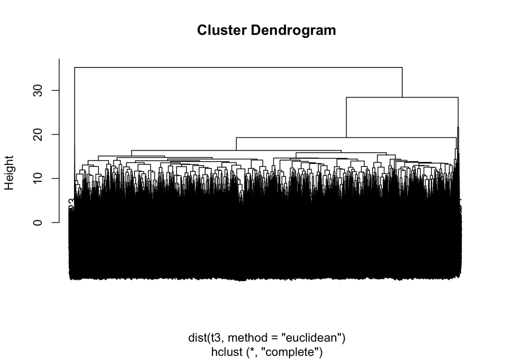

```r
train_sample <- training[sample(nrow(training), 0.7*dim(training)[1]), ]
t3 <- scale(train_sample, center = TRUE, scale = TRUE)

hac_output <- hclust(dist(t3, method = "euclidean"), method = "complete")
plot(hac_output)
```

```r
hac_cut <- cutree(hac_output, 2)
```

##### Best performing models

| Model | Hyper-parameters |
| --- | --- |
| k-means | centers = 2, iter.max = 10 |
| HAC | distance = euclidean, method = complete |

- Performance of k-means algorithm can be determined by sum of squared errors. If SSE is low, the data points within the cluster are identical
- Performance of HAC can be measured using silhouette coefficient

##### Repurposing unsupervised learning algorithms for classification

- Clustering algorithms can be repurposed for classification based on the target variable in the training dataset. Depending on differnt values of target variables it can be decided which cluster represents what value of the target variable by measuring entropy or confusion matrix
- Another way could be randomly asign the target variable values to the clusters and calculate number of true positives and true negatives classified by each cluster. If true positive is greater, then the target variable value assigned to the cluster is correct
- The clusters can be used for classification by determining the distance of the test data points from the clusters and assigning them to the cluster with smallest distance

#### Decision tree induction

```r
library(caret)
library(rpart)
dt_model <- train(RainTomorrow ~ ., data = wfor_train, metric = "Accuracy", method = "rpart")
print(dt_model)
```

```
## CART
##
## 51957 samples
##    15 predictor
##     2 classes: 'No', 'Yes'
##
## No pre-processing
## Resampling: Bootstrapped (25 reps)
## Summary of sample sizes: 51957, 51957, 51957, 51957, 51957, 51957, ...
## Resampling results across tuning parameters:
##
##   cp           Accuracy   Kappa
##   0.008269645  0.7410167  0.4814985
##   0.018087400  0.7287466  0.4563729
##   0.434646286  0.6622243  0.3178300
##
## Accuracy was used to select the optimal model using the largest value.
## The final value used for the model was cp = 0.008269645.
```

```r
print(dt_model$finalModel)
```

```
## n= 51957
##
## node), split, n, loss, yval, (yprob)
##       * denotes terminal node
##
##  1) root 51957 25515 No (0.5089208 0.4910792)
##    2) Humidity< 64.5 31911  9947 No (0.6882893 0.3117107)
##      4) Rainfall< 0.35 23819  5869 No (0.7536001 0.2463999) *
##      5) Rainfall>=0.35 8092  4014 Yes (0.4960455 0.5039545)
##       10) WindGustSpeed< 41.5 3477  1309 No (0.6235260 0.3764740) *
##       11) WindGustSpeed>=41.5 4615  1846 Yes (0.4000000 0.6000000) *
##    3) Humidity>=64.5 20046  4478 Yes (0.2233862 0.7766138) *
```

##### ROC curve and AUC

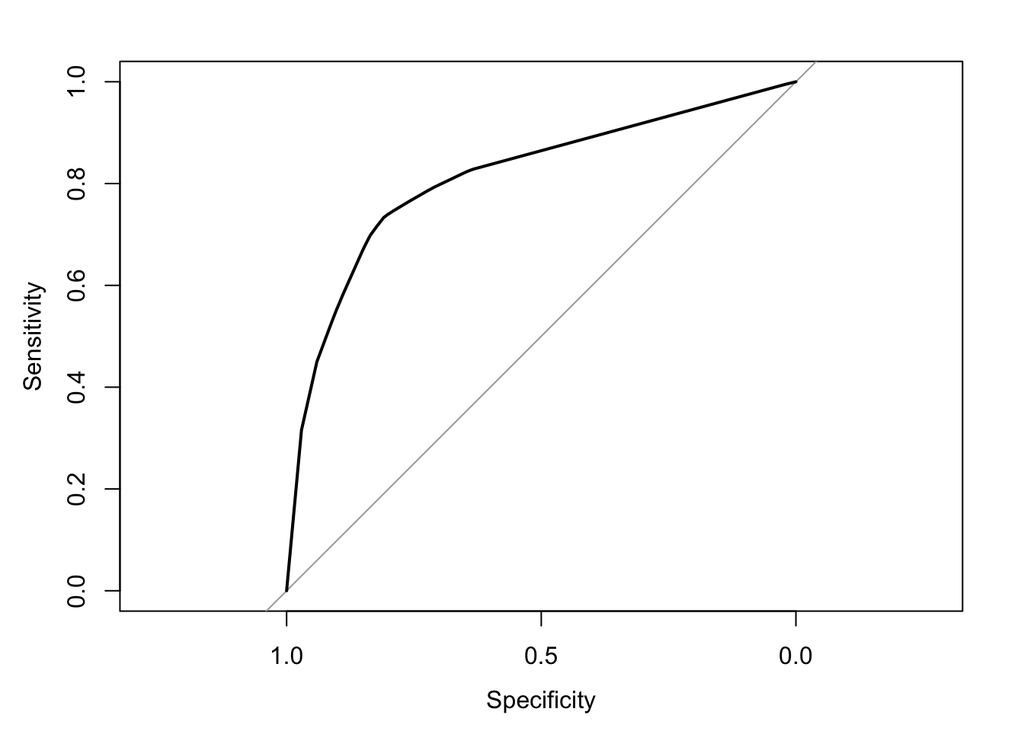

```r
library(pROC)
dt_model <- train(RainTomorrow ~ ., data = wfor_train, method = "rpart", tuneLength = 10)
dt_pred_prob <- predict(dt_model, newdata = wfor_train, type = "prob")
roc_curve <- roc(wfor_train$RainTomorrow, dt_pred_prob$Yes)
plot(roc_curve)
```

Area under the curve

```r
auc(roc_curve)
```

```
## Area under the curve: 0.8133
```

## Section 3: Prediction and interpretation

#### Reading the testing data from csv file

```r
wfor_test <- read_csv("Weather Forecast Testing.csv", col_types = cols())
```

##### Imputing missing values

```r
sum(!complete.cases(wfor_test))
```

```
## [1] 7679
```

Replacing missing values based on location

```r
wfor_test <- wfor_test %>%
  group_by(Location) %>%
  mutate(
    MinTemp = impute.mean(MinTemp),
    MaxTemp = impute.mean(MaxTemp),
    Rainfall = impute.mean(Rainfall),
    Evaporation = impute.mean(Evaporation),
    Sunshine = impute.mean(Sunshine),
    WindGustSpeed = round(impute.mean(WindGustSpeed)),
    WindSpeed = round(impute.mean(WindSpeed)),
    Humidity = round(impute.mean(Humidity)),
    Pressure = round(impute.mean(Pressure)),
    Cloud = round(impute.mean(Cloud)),
    Temp = impute.mean(Temp),
    WindGustDir = impute.mode(WindGustDir),
    WindDir = impute.mode(WindDir),
    RainToday = impute.mode(RainToday)
  )
```

Replacing remaining with respect to the entire dataset

```r
wfor_test$Evaporation <- impute.mean(wfor_test$Evaporation)
wfor_test$Sunshine <- impute.mean(wfor_test$Sunshine)
wfor_test$WindGustSpeed <- impute.mean(wfor_test$WindGustSpeed)
wfor_test$Pressure <- round(impute.mean(wfor_test$Pressure))
wfor_test$Cloud <- round(impute.mean(wfor_test$Cloud))
wfor_test$WindGustDir <- impute.mode(wfor_test$WindGustDir)
```

#### Prediction using decision tree

```r
dt_predict <- predict(dt_model, newdata = wfor_test, na.action = na.omit, type = "raw")
head(dt_predict, 5)
```

```
## [1] Yes Yes No  No  No
## Levels: No Yes
```

RainTomorrow is predicted as either “Yes” or “No”

#### Prediction using k-means

Determining the two clusters of k-means

```r
c1 <- wfor_train[(km_output$cluster==1), ]
c1 %>%
  group_by(RainTomorrow) %>%
  count()
```

```
## # A tibble: 2 x 2
## # Groups:   RainTomorrow [2]
##   RainTomorrow     n
##   <chr>        <int>
## 1 No           23364
## 2 Yes           3749
```

```r
c2 <- wfor_train[(km_output$cluster==2), ]
c2 %>%
  group_by(RainTomorrow) %>%
  count()
```

```
## # A tibble: 2 x 2
## # Groups:   RainTomorrow [2]
##   RainTomorrow     n
##   <chr>        <int>
## 1 No            3078
## 2 Yes          21766
```

```r
c1_avg_rainfall <- mean(c1$Rainfall)
c1_avg_humidity <- mean(c1$Humidity)
c1_avg_temp  <- mean(c1$Temp)
```

```r
km_pred <- wfor_test[(((wfor_test$Rainfall > c1_avg_rainfall) & (wfor_test$Humidity > c1_avg_humidity)) | (wfor_test$Temp < c1_avg_temp)), ]
```

#### Prediction using HAC

Determining the two clusters of HAC

```r
hc1 <- train_sample[(hac_cut == 1), ]
hc1 %>%
  group_by(RainTomorrow.Yes) %>%
  count()
```

```
## # A tibble: 2 x 2
## # Groups:   RainTomorrow.Yes [2]
##   RainTomorrow.Yes     n
##              <dbl> <int>
## 1                0 18519
## 2                1 17816
```

In cluster 1, true negatives are greater than true positives. We can say that cluster 1 represents RainTomorrow = No

```r
hc2 <- train_sample[(hac_cut == 2), ]
hc2 %>%
  group_by(RainTomorrow.Yes) %>%
  count()
```

```
## # A tibble: 2 x 2
## # Groups:   RainTomorrow.Yes [2]
##   RainTomorrow.Yes     n
##              <dbl> <int>
## 1                0     3
## 2                1    31
```

In case of cluster 2, true positives are greater than true negatives. We can say that cluster two represents RainTomorrow = Yes

- Calculating average of Rainfall, Humidity and Temp for cluster 1 (RainTomorrow = No) and comparting the testing data with these values
- If Rainfall and Humidity is less or Temp is greater than the respective averages, then we can say that the data point belongs to cluster 1 i.e., RainTomorrow = No

```r
hc1_avg_rainfall <- mean(hc1$Rainfall)
hc1_avg_humidity <- mean(hc1$Humidity)
hc1_avg_temp  <- mean(hc1$Temp)
```

Finding the data points in test data that belong to cluster 1 (RainTomorrow = No)

```r
hac_pred <- wfor_test[(((wfor_test$Rainfall < hc1_avg_rainfall) & (wfor_test$Humidity < hc1_avg_humidity)) | (wfor_test$Temp > hc1_avg_temp)), ]
```

#### Combining the prediction made by all the three models

```r
prediction <- data.frame(ID = wfor_test$ID)
prediction$kmeans <- NA
prediction$kmeans[km_pred$ID] <- "Yes"
prediction$kmeans[is.na(prediction$kmeans)] <- "No"
prediction$HAC <- NA
prediction$HAC[hac_pred$ID] <- "No"
prediction$HAC[is.na(prediction$HAC)] <- "Yes"
prediction$DT <- dt_predict
```

#### Writing prediction results to csv file

```r
write.csv(prediction, "prediction.csv")
```